# Risk Factor Analysis

## Outcome Variable

**Outcome Variable:** ever_wasted

## Predictor Variables

**Intervention Variable:** single

**Adjustment Set:**

- arm
- W_mage
- meducyrs
- feducyrs
- W_mhtcm
- W_mwtkg
- W_mbmi
- delta_W_mage
- delta_meducyrs
- delta_feducyrs
- delta_W_mhtcm
- delta_W_mwtkg
- delta_W_mbmi

## Stratifying Variables

The analysis was stratified on these variable(s):

- agecat
- studyid
- country

## Data Summary

| agecat | studyid | country | single | ever_wasted | n_cell | n |
| --- | --- | --- | --- | --- | --- | --- |
| 0-24 months | COHORTS | GUATEMALA | 0 | 0 | 804 | 1197 |
| 0-24 months | COHORTS | GUATEMALA | 0 | 1 | 295 | 1197 |
| 0-24 months | COHORTS | GUATEMALA | 1 | 0 | 77 | 1197 |
| 0-24 months | COHORTS | GUATEMALA | 1 | 1 | 21 | 1197 |
| 0-24 months | COHORTS | INDIA | 0 | 0 | 3568 | 5376 |
| 0-24 months | COHORTS | INDIA | 0 | 1 | 1799 | 5376 |
| 0-24 months | COHORTS | INDIA | 1 | 0 | 5 | 5376 |
| 0-24 months | COHORTS | INDIA | 1 | 1 | 4 | 5376 |
| 0-24 months | COHORTS | PHILIPPINES | 0 | 0 | 1754 | 3005 |
| 0-24 months | COHORTS | PHILIPPINES | 0 | 1 | 1177 | 3005 |
| 0-24 months | COHORTS | PHILIPPINES | 1 | 0 | 41 | 3005 |
| 0-24 months | COHORTS | PHILIPPINES | 1 | 1 | 33 | 3005 |
| 0-24 months | Guatemala BSC | GUATEMALA | 0 | 0 | 225 | 282 |
| 0-24 months | Guatemala BSC | GUATEMALA | 0 | 1 | 27 | 282 |
| 0-24 months | Guatemala BSC | GUATEMALA | 1 | 0 | 27 | 282 |
| 0-24 months | Guatemala BSC | GUATEMALA | 1 | 1 | 3 | 282 |
| 0-24 months | JiVitA-4 | BANGLADESH | 0 | 0 | 3734 | 5424 |
| 0-24 months | JiVitA-4 | BANGLADESH | 0 | 1 | 1682 | 5424 |
| 0-24 months | JiVitA-4 | BANGLADESH | 1 | 0 | 7 | 5424 |
| 0-24 months | JiVitA-4 | BANGLADESH | 1 | 1 | 1 | 5424 |
| 0-24 months | MAL-ED | BANGLADESH | 0 | 0 | 176 | 263 |
| 0-24 months | MAL-ED | BANGLADESH | 0 | 1 | 87 | 263 |
| 0-24 months | MAL-ED | BANGLADESH | 1 | 0 | 0 | 263 |
| 0-24 months | MAL-ED | BANGLADESH | 1 | 1 | 0 | 263 |
| 0-24 months | MAL-ED | BRAZIL | 0 | 0 | 182 | 233 |
| 0-24 months | MAL-ED | BRAZIL | 0 | 1 | 15 | 233 |
| 0-24 months | MAL-ED | BRAZIL | 1 | 0 | 31 | 233 |
| 0-24 months | MAL-ED | BRAZIL | 1 | 1 | 5 | 233 |
| 0-24 months | MAL-ED | INDIA | 0 | 0 | 130 | 249 |
| 0-24 months | MAL-ED | INDIA | 0 | 1 | 119 | 249 |

[output cut: 150 more lines]

The following strata were considered:

- agecat: 0-24 months, studyid: COHORTS, country: GUATEMALA
- agecat: 0-24 months, studyid: COHORTS, country: INDIA
- agecat: 0-24 months, studyid: COHORTS, country: PHILIPPINES
- agecat: 0-24 months, studyid: Guatemala BSC, country: GUATEMALA
- agecat: 0-24 months, studyid: JiVitA-4, country: BANGLADESH
- agecat: 0-24 months, studyid: MAL-ED, country: BANGLADESH
- agecat: 0-24 months, studyid: MAL-ED, country: BRAZIL
- agecat: 0-24 months, studyid: MAL-ED, country: INDIA
- agecat: 0-24 months, studyid: MAL-ED, country: NEPAL
- agecat: 0-24 months, studyid: MAL-ED, country: PERU
- agecat: 0-24 months, studyid: MAL-ED, country: SOUTH AFRICA
- agecat: 0-24 months, studyid: MAL-ED, country: TANZANIA, UNITED REPUBLIC OF
- agecat: 0-24 months, studyid: PROBIT, country: BELARUS
- agecat: 0-24 months, studyid: TanzaniaChild2, country: TANZANIA, UNITED REPUBLIC OF
- agecat: 0-24 months, studyid: ZVITAMBO, country: ZIMBABWE
- agecat: 0-6 months, studyid: COHORTS, country: GUATEMALA
- agecat: 0-6 months, studyid: COHORTS, country: INDIA
- agecat: 0-6 months, studyid: COHORTS, country: PHILIPPINES
- agecat: 0-6 months, studyid: Guatemala BSC, country: GUATEMALA
- agecat: 0-6 months, studyid: JiVitA-4, country: BANGLADESH
- agecat: 0-6 months, studyid: MAL-ED, country: BANGLADESH
- agecat: 0-6 months, studyid: MAL-ED, country: BRAZIL
- agecat: 0-6 months, studyid: MAL-ED, country: INDIA
- agecat: 0-6 months, studyid: MAL-ED, country: NEPAL
- agecat: 0-6 months, studyid: MAL-ED, country: PERU
- agecat: 0-6 months, studyid: MAL-ED, country: SOUTH AFRICA
- agecat: 0-6 months, studyid: MAL-ED, country: TANZANIA, UNITED REPUBLIC OF
- agecat: 0-6 months, studyid: PROBIT, country: BELARUS
- agecat: 0-6 months, studyid: TanzaniaChild2, country: TANZANIA, UNITED REPUBLIC OF
- agecat: 0-6 months, studyid: ZVITAMBO, country: ZIMBABWE
- agecat: 6-24 months, studyid: COHORTS, country: GUATEMALA
- agecat: 6-24 months, studyid: COHORTS, country: INDIA
- agecat: 6-24 months, studyid: COHORTS, country: PHILIPPINES
- agecat: 6-24 months, studyid: Guatemala BSC, country: GUATEMALA
- agecat: 6-24 months, studyid: JiVitA-4, country: BANGLADESH
- agecat: 6-24 months, studyid: MAL-ED, country: BANGLADESH
- agecat: 6-24 months, studyid: MAL-ED, country: BRAZIL
- agecat: 6-24 months, studyid: MAL-ED, country: INDIA
- agecat: 6-24 months, studyid: MAL-ED, country: NEPAL
- agecat: 6-24 months, studyid: MAL-ED, country: PERU
- agecat: 6-24 months, studyid: MAL-ED, country: SOUTH AFRICA
- agecat: 6-24 months, studyid: MAL-ED, country: TANZANIA, UNITED REPUBLIC OF
- agecat: 6-24 months, studyid: PROBIT, country: BELARUS
- agecat: 6-24 months, studyid: TanzaniaChild2, country: TANZANIA, UNITED REPUBLIC OF
- agecat: 6-24 months, studyid: ZVITAMBO, country: ZIMBABWE

### Dropped Strata

Some strata were dropped due to rare outcomes:

- agecat: 0-24 months, studyid: COHORTS, country: INDIA
- agecat: 0-24 months, studyid: Guatemala BSC, country: GUATEMALA
- agecat: 0-24 months, studyid: JiVitA-4, country: BANGLADESH
- agecat: 0-24 months, studyid: MAL-ED, country: BANGLADESH
- agecat: 0-24 months, studyid: MAL-ED, country: INDIA
- agecat: 0-24 months, studyid: MAL-ED, country: NEPAL
- agecat: 0-24 months, studyid: MAL-ED, country: TANZANIA, UNITED REPUBLIC OF
- agecat: 0-6 months, studyid: COHORTS, country: INDIA
- agecat: 0-6 months, studyid: Guatemala BSC, country: GUATEMALA
- agecat: 0-6 months, studyid: JiVitA-4, country: BANGLADESH
- agecat: 0-6 months, studyid: MAL-ED, country: BANGLADESH
- agecat: 0-6 months, studyid: MAL-ED, country: BRAZIL
- agecat: 0-6 months, studyid: MAL-ED, country: INDIA
- agecat: 0-6 months, studyid: MAL-ED, country: NEPAL
- agecat: 0-6 months, studyid: MAL-ED, country: PERU
- agecat: 0-6 months, studyid: MAL-ED, country: TANZANIA, UNITED REPUBLIC OF
- agecat: 6-24 months, studyid: COHORTS, country: INDIA
- agecat: 6-24 months, studyid: Guatemala BSC, country: GUATEMALA
- agecat: 6-24 months, studyid: JiVitA-4, country: BANGLADESH
- agecat: 6-24 months, studyid: MAL-ED, country: BANGLADESH
- agecat: 6-24 months, studyid: MAL-ED, country: BRAZIL
- agecat: 6-24 months, studyid: MAL-ED, country: INDIA
- agecat: 6-24 months, studyid: MAL-ED, country: NEPAL
- agecat: 6-24 months, studyid: MAL-ED, country: PERU
- agecat: 6-24 months, studyid: MAL-ED, country: TANZANIA, UNITED REPUBLIC OF

## Methods Detail

We’re interested in the causal parameters $E[Y_a]$ for all values of $a \in \mathcal{A}$. These parameters represent the mean outcome if, possibly contrary to fact, we intervened to set all units to have $A=a$. Under the randomization and positivity assumptions, these are identified by the statistical parameters $\psi_a=E_W[E_{Y|A,W}(Y|A=a,W)]$. In addition, we’re interested in the mean of $Y$, $E[Y]$ under no intervention (the observed mean). We will estimate these parameters by using SuperLearner to fit the relevant likelihood factors – $E_{Y|A,W}(Y|A=a,W)$ and $p(A=a|W)$, and then updating our likelihood fit using a joint TMLE.

For unadjusted analyses ($W=\{\}$), initial likelihoods were estimated using Lrnr_glm to estimate the simple $E(Y|A)$ and Lrnr_mean to estimate $p(A)$. For adjusted analyses, a small library containing Lrnr_glmnet, Lrnr_xgboost, and Lrnr_mean was used.

Having estimated these parameters, we will then use the delta method to estimate relative risks and attributable risks relative to a prespecified baseline level of $A$.

# Results Detail

## Results Plots

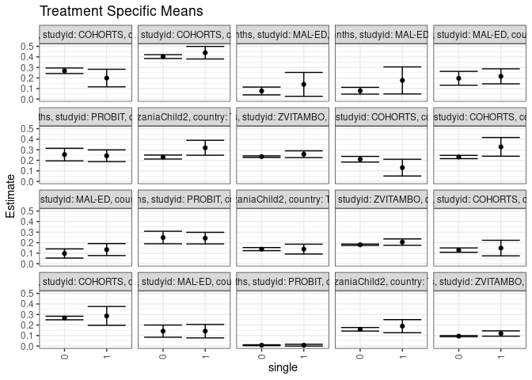

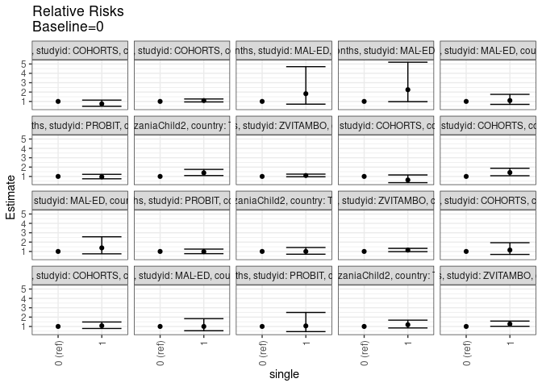

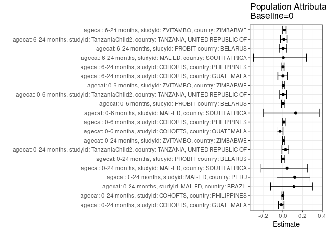

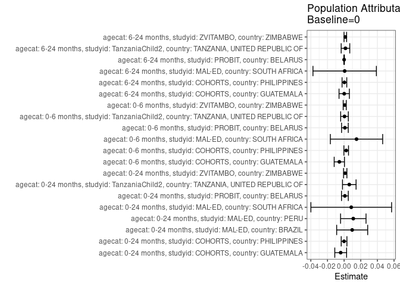

## Results Table

### Parameter: TSM

| agecat | studyid | country | intervention_level | baseline_level | estimate | ci_lower | ci_upper |
| --- | --- | --- | --- | --- | --- | --- | --- |
| 0-24 months | COHORTS | GUATEMALA | 0 | NA | 0.2681003 | 0.2418820 | 0.2943186 |
| 0-24 months | COHORTS | GUATEMALA | 1 | NA | 0.1988127 | 0.1154413 | 0.2821841 |
| 0-24 months | COHORTS | PHILIPPINES | 0 | NA | 0.4027052 | 0.3844644 | 0.4209459 |
| 0-24 months | COHORTS | PHILIPPINES | 1 | NA | 0.4397172 | 0.3800761 | 0.4993583 |
| 0-24 months | MAL-ED | BRAZIL | 0 | NA | 0.0761421 | 0.0390259 | 0.1132584 |
| 0-24 months | MAL-ED | BRAZIL | 1 | NA | 0.1388889 | 0.0256764 | 0.2521013 |
| 0-24 months | MAL-ED | PERU | 0 | NA | 0.0783582 | 0.0461309 | 0.1105855 |
| 0-24 months | MAL-ED | PERU | 1 | NA | 0.1764706 | 0.0481180 | 0.3048232 |
| 0-24 months | MAL-ED | SOUTH AFRICA | 0 | NA | 0.1965297 | 0.1309188 | 0.2621407 |
| 0-24 months | MAL-ED | SOUTH AFRICA | 1 | NA | 0.2153165 | 0.1438649 | 0.2867682 |
| 0-24 months | PROBIT | BELARUS | 0 | NA | 0.2544635 | 0.1949952 | 0.3139319 |
| 0-24 months | PROBIT | BELARUS | 1 | NA | 0.2431268 | 0.1873380 | 0.2989156 |
| 0-24 months | TanzaniaChild2 | TANZANIA, UNITED REPUBLIC OF | 0 | NA | 0.2308292 | 0.2118488 | 0.2498096 |
| 0-24 months | TanzaniaChild2 | TANZANIA, UNITED REPUBLIC OF | 1 | NA | 0.3189286 | 0.2480474 | 0.3898097 |
| 0-24 months | ZVITAMBO | ZIMBABWE | 0 | NA | 0.2351056 | 0.2277795 | 0.2424316 |
| 0-24 months | ZVITAMBO | ZIMBABWE | 1 | NA | 0.2579047 | 0.2259128 | 0.2898965 |
| 0-6 months | COHORTS | GUATEMALA | 0 | NA | 0.2101124 | 0.1833337 | 0.2368910 |
| 0-6 months | COHORTS | GUATEMALA | 1 | NA | 0.1304348 | 0.0509292 | 0.2099404 |
| 0-6 months | COHORTS | PHILIPPINES | 0 | NA | 0.2311714 | 0.2157914 | 0.2465514 |
| 0-6 months | COHORTS | PHILIPPINES | 1 | NA | 0.3277321 | 0.2389028 | 0.4165614 |
| 0-6 months | MAL-ED | SOUTH AFRICA | 0 | NA | 0.0972634 | 0.0536849 | 0.1408419 |
| 0-6 months | MAL-ED | SOUTH AFRICA | 1 | NA | 0.1343928 | 0.0773027 | 0.1914829 |
| 0-6 months | PROBIT | BELARUS | 0 | NA | 0.2490419 | 0.1895499 | 0.3085339 |
| 0-6 months | PROBIT | BELARUS | 1 | NA | 0.2432131 | 0.1883088 | 0.2981174 |
| 0-6 months | TanzaniaChild2 | TANZANIA, UNITED REPUBLIC OF | 0 | NA | 0.1389008 | 0.1242664 | 0.1535353 |
| 0-6 months | TanzaniaChild2 | TANZANIA, UNITED REPUBLIC OF | 1 | NA | 0.1388809 | 0.0921767 | 0.1855850 |
| 0-6 months | ZVITAMBO | ZIMBABWE | 0 | NA | 0.1799557 | 0.1733012 | 0.1866103 |
| 0-6 months | ZVITAMBO | ZIMBABWE | 1 | NA | 0.2053950 | 0.1752311 | 0.2355590 |
| 6-24 months | COHORTS | GUATEMALA | 0 | NA | 0.1294907 | 0.1087606 | 0.1502208 |
| 6-24 months | COHORTS | GUATEMALA | 1 | NA | 0.1488668 | 0.0750192 | 0.2227144 |
| 6-24 months | COHORTS | PHILIPPINES | 0 | NA | 0.2666633 | 0.2498616 | 0.2834650 |
| 6-24 months | COHORTS | PHILIPPINES | 1 | NA | 0.2865811 | 0.1973252 | 0.3758371 |
| 6-24 months | MAL-ED | SOUTH AFRICA | 0 | NA | 0.1421768 | 0.0843849 | 0.1999688 |
| 6-24 months | MAL-ED | SOUTH AFRICA | 1 | NA | 0.1420090 | 0.0778365 | 0.2061816 |
| 6-24 months | PROBIT | BELARUS | 0 | NA | 0.0083548 | 0.0044070 | 0.0123026 |
| 6-24 months | PROBIT | BELARUS | 1 | NA | 0.0088365 | 0.0002568 | 0.0174162 |
| 6-24 months | TanzaniaChild2 | TANZANIA, UNITED REPUBLIC OF | 0 | NA | 0.1596158 | 0.1427967 | 0.1764349 |
| 6-24 months | TanzaniaChild2 | TANZANIA, UNITED REPUBLIC OF | 1 | NA | 0.1891290 | 0.1269302 | 0.2513278 |
| 6-24 months | ZVITAMBO | ZIMBABWE | 0 | NA | 0.0945347 | 0.0888345 | 0.1002349 |
| 6-24 months | ZVITAMBO | ZIMBABWE | 1 | NA | 0.1195892 | 0.0944620 | 0.1447164 |

### Parameter: E(Y)

| agecat | studyid | country | intervention_level | baseline_level | estimate | ci_lower | ci_upper |
| --- | --- | --- | --- | --- | --- | --- | --- |
| 0-24 months | COHORTS | GUATEMALA | NA | NA | 0.2639933 | 0.2390117 | 0.2889749 |
| 0-24 months | COHORTS | PHILIPPINES | NA | NA | 0.4026622 | 0.3851243 | 0.4202002 |
| 0-24 months | MAL-ED | BRAZIL | NA | NA | 0.0858369 | 0.0497913 | 0.1218826 |
| 0-24 months | MAL-ED | PERU | NA | NA | 0.0894040 | 0.0571706 | 0.1216374 |
| 0-24 months | MAL-ED | SOUTH AFRICA | NA | NA | 0.2051282 | 0.1602507 | 0.2500058 |
| 0-24 months | PROBIT | BELARUS | NA | NA | 0.2554148 | 0.1971257 | 0.3137039 |
| 0-24 months | TanzaniaChild2 | TANZANIA, UNITED REPUBLIC OF | NA | NA | 0.2370526 | 0.2199455 | 0.2541598 |
| 0-24 months | ZVITAMBO | ZIMBABWE | NA | NA | 0.2364291 | 0.2293629 | 0.2434953 |
| 0-6 months | COHORTS | GUATEMALA | NA | NA | 0.2043796 | 0.1788445 | 0.2299146 |
| 0-6 months | COHORTS | PHILIPPINES | NA | NA | 0.2336884 | 0.2185531 | 0.2488237 |
| 0-6 months | MAL-ED | SOUTH AFRICA | NA | NA | 0.1121795 | 0.0771053 | 0.1472536 |
| 0-6 months | PROBIT | BELARUS | NA | NA | 0.2500148 | 0.1915461 | 0.3084835 |
| 0-6 months | TanzaniaChild2 | TANZANIA, UNITED REPUBLIC OF | NA | NA | 0.1393684 | 0.1254369 | 0.1532999 |
| 0-6 months | ZVITAMBO | ZIMBABWE | NA | NA | 0.1806915 | 0.1742710 | 0.1871119 |
| 6-24 months | COHORTS | GUATEMALA | NA | NA | 0.1296130 | 0.1098539 | 0.1493721 |
| 6-24 months | COHORTS | PHILIPPINES | NA | NA | 0.2670270 | 0.2505637 | 0.2834903 |
| 6-24 months | MAL-ED | SOUTH AFRICA | NA | NA | 0.1428571 | 0.1001583 | 0.1855560 |
| 6-24 months | PROBIT | BELARUS | NA | NA | 0.0083745 | 0.0044130 | 0.0123360 |
| 6-24 months | TanzaniaChild2 | TANZANIA, UNITED REPUBLIC OF | NA | NA | 0.1612581 | 0.1451483 | 0.1773679 |
| 6-24 months | ZVITAMBO | ZIMBABWE | NA | NA | 0.0959985 | 0.0904349 | 0.1015621 |

### Parameter: RR

| agecat | studyid | country | intervention_level | baseline_level | estimate | ci_lower | ci_upper |
| --- | --- | --- | --- | --- | --- | --- | --- |
| 0-24 months | COHORTS | GUATEMALA | 0 | 0 | 1.0000000 | 1.0000000 | 1.000000 |
| 0-24 months | COHORTS | GUATEMALA | 1 | 0 | 0.7415609 | 0.4821345 | 1.140579 |
| 0-24 months | COHORTS | PHILIPPINES | 0 | 0 | 1.0000000 | 1.0000000 | 1.000000 |
| 0-24 months | COHORTS | PHILIPPINES | 1 | 0 | 1.0919084 | 0.9464503 | 1.259722 |
| 0-24 months | MAL-ED | BRAZIL | 0 | 0 | 1.0000000 | 1.0000000 | 1.000000 |
| 0-24 months | MAL-ED | BRAZIL | 1 | 0 | 1.8240741 | 0.7056101 | 4.715418 |
| 0-24 months | MAL-ED | PERU | 0 | 0 | 1.0000000 | 1.0000000 | 1.000000 |
| 0-24 months | MAL-ED | PERU | 1 | 0 | 2.2521008 | 0.9765802 | 5.193591 |
| 0-24 months | MAL-ED | SOUTH AFRICA | 0 | 0 | 1.0000000 | 1.0000000 | 1.000000 |
| 0-24 months | MAL-ED | SOUTH AFRICA | 1 | 0 | 1.0955925 | 0.6839812 | 1.754906 |
| 0-24 months | PROBIT | BELARUS | 0 | 0 | 1.0000000 | 1.0000000 | 1.000000 |
| 0-24 months | PROBIT | BELARUS | 1 | 0 | 0.9554485 | 0.7460377 | 1.223640 |
| 0-24 months | TanzaniaChild2 | TANZANIA, UNITED REPUBLIC OF | 0 | 0 | 1.0000000 | 1.0000000 | 1.000000 |
| 0-24 months | TanzaniaChild2 | TANZANIA, UNITED REPUBLIC OF | 1 | 0 | 1.3816647 | 1.0902693 | 1.750941 |
| 0-24 months | ZVITAMBO | ZIMBABWE | 0 | 0 | 1.0000000 | 1.0000000 | 1.000000 |
| 0-24 months | ZVITAMBO | ZIMBABWE | 1 | 0 | 1.0969739 | 0.9653400 | 1.246557 |
| 0-6 months | COHORTS | GUATEMALA | 0 | 0 | 1.0000000 | 1.0000000 | 1.000000 |
| 0-6 months | COHORTS | GUATEMALA | 1 | 0 | 0.6207859 | 0.3330396 | 1.157145 |
| 0-6 months | COHORTS | PHILIPPINES | 0 | 0 | 1.0000000 | 1.0000000 | 1.000000 |
| 0-6 months | COHORTS | PHILIPPINES | 1 | 0 | 1.4177016 | 1.0724577 | 1.874086 |
| 0-6 months | MAL-ED | SOUTH AFRICA | 0 | 0 | 1.0000000 | 1.0000000 | 1.000000 |
| 0-6 months | MAL-ED | SOUTH AFRICA | 1 | 0 | 1.3817406 | 0.7442061 | 2.565428 |
| 0-6 months | PROBIT | BELARUS | 0 | 0 | 1.0000000 | 1.0000000 | 1.000000 |
| 0-6 months | PROBIT | BELARUS | 1 | 0 | 0.9765951 | 0.7630431 | 1.249914 |
| 0-6 months | TanzaniaChild2 | TANZANIA, UNITED REPUBLIC OF | 0 | 0 | 1.0000000 | 1.0000000 | 1.000000 |
| 0-6 months | TanzaniaChild2 | TANZANIA, UNITED REPUBLIC OF | 1 | 0 | 0.9998565 | 0.7028866 | 1.422296 |
| 0-6 months | ZVITAMBO | ZIMBABWE | 0 | 0 | 1.0000000 | 1.0000000 | 1.000000 |
| 0-6 months | ZVITAMBO | ZIMBABWE | 1 | 0 | 1.1413642 | 0.9809963 | 1.327948 |
| 6-24 months | COHORTS | GUATEMALA | 0 | 0 | 1.0000000 | 1.0000000 | 1.000000 |
| 6-24 months | COHORTS | GUATEMALA | 1 | 0 | 1.1496329 | 0.6827679 | 1.935732 |
| 6-24 months | COHORTS | PHILIPPINES | 0 | 0 | 1.0000000 | 1.0000000 | 1.000000 |
| 6-24 months | COHORTS | PHILIPPINES | 1 | 0 | 1.0746927 | 0.7821498 | 1.476654 |
| 6-24 months | MAL-ED | SOUTH AFRICA | 0 | 0 | 1.0000000 | 1.0000000 | 1.000000 |
| 6-24 months | MAL-ED | SOUTH AFRICA | 1 | 0 | 0.9988196 | 0.5441882 | 1.833264 |
| 6-24 months | PROBIT | BELARUS | 0 | 0 | 1.0000000 | 1.0000000 | 1.000000 |
| 6-24 months | PROBIT | BELARUS | 1 | 0 | 1.0576589 | 0.4478582 | 2.497760 |
| 6-24 months | TanzaniaChild2 | TANZANIA, UNITED REPUBLIC OF | 0 | 0 | 1.0000000 | 1.0000000 | 1.000000 |
| 6-24 months | TanzaniaChild2 | TANZANIA, UNITED REPUBLIC OF | 1 | 0 | 1.1849014 | 0.8391771 | 1.673057 |
| 6-24 months | ZVITAMBO | ZIMBABWE | 0 | 0 | 1.0000000 | 1.0000000 | 1.000000 |
| 6-24 months | ZVITAMBO | ZIMBABWE | 1 | 0 | 1.2650295 | 1.0167936 | 1.573869 |

### Parameter: PAR

| agecat | studyid | country | intervention_level | baseline_level | estimate | ci_lower | ci_upper |
| --- | --- | --- | --- | --- | --- | --- | --- |
| 0-24 months | COHORTS | GUATEMALA | 0 | NA | -0.0041070 | -0.0112096 | 0.0029957 |
| 0-24 months | COHORTS | PHILIPPINES | 0 | NA | -0.0000429 | -0.0034588 | 0.0033729 |
| 0-24 months | MAL-ED | BRAZIL | 0 | NA | 0.0096948 | -0.0089432 | 0.0283328 |
| 0-24 months | MAL-ED | PERU | 0 | NA | 0.0110458 | -0.0042594 | 0.0263510 |
| 0-24 months | MAL-ED | SOUTH AFRICA | 0 | NA | 0.0085985 | -0.0399093 | 0.0571062 |
| 0-24 months | PROBIT | BELARUS | 0 | NA | 0.0009513 | -0.0031233 | 0.0050259 |
| 0-24 months | TanzaniaChild2 | TANZANIA, UNITED REPUBLIC OF | 0 | NA | 0.0062234 | -0.0019354 | 0.0143822 |
| 0-24 months | ZVITAMBO | ZIMBABWE | 0 | NA | 0.0013235 | -0.0006998 | 0.0033469 |
| 0-6 months | COHORTS | GUATEMALA | 0 | NA | -0.0057328 | -0.0119082 | 0.0004426 |
| 0-6 months | COHORTS | PHILIPPINES | 0 | NA | 0.0025170 | -0.0002656 | 0.0052996 |
| 0-6 months | MAL-ED | SOUTH AFRICA | 0 | NA | 0.0149161 | -0.0165301 | 0.0463623 |
| 0-6 months | PROBIT | BELARUS | 0 | NA | 0.0009729 | -0.0030407 | 0.0049866 |
| 0-6 months | TanzaniaChild2 | TANZANIA, UNITED REPUBLIC OF | 0 | NA | 0.0004676 | -0.0041274 | 0.0050626 |
| 0-6 months | ZVITAMBO | ZIMBABWE | 0 | NA | 0.0007357 | -0.0011020 | 0.0025734 |
| 6-24 months | COHORTS | GUATEMALA | 0 | NA | 0.0001222 | -0.0060958 | 0.0063403 |
| 6-24 months | COHORTS | PHILIPPINES | 0 | NA | 0.0003637 | -0.0024663 | 0.0031937 |
| 6-24 months | MAL-ED | SOUTH AFRICA | 0 | NA | 0.0006803 | -0.0374416 | 0.0388022 |
| 6-24 months | PROBIT | BELARUS | 0 | NA | 0.0000197 | -0.0002915 | 0.0003309 |
| 6-24 months | TanzaniaChild2 | TANZANIA, UNITED REPUBLIC OF | 0 | NA | 0.0016423 | -0.0035065 | 0.0067911 |
| 6-24 months | ZVITAMBO | ZIMBABWE | 0 | NA | 0.0014638 | -0.0000993 | 0.0030269 |

### Parameter: PAF

| agecat | studyid | country | intervention_level | baseline_level | estimate | ci_lower | ci_upper |
| --- | --- | --- | --- | --- | --- | --- | --- |
| 0-24 months | COHORTS | GUATEMALA | 0 | NA | -0.0155571 | -0.0428078 | 0.0109815 |
| 0-24 months | COHORTS | PHILIPPINES | 0 | NA | -0.0001066 | -0.0086254 | 0.0083402 |
| 0-24 months | MAL-ED | BRAZIL | 0 | NA | 0.1129442 | -0.1275143 | 0.3021215 |
| 0-24 months | MAL-ED | PERU | 0 | NA | 0.1235489 | -0.0596047 | 0.2750443 |
| 0-24 months | MAL-ED | SOUTH AFRICA | 0 | NA | 0.0419175 | -0.2263579 | 0.2515056 |
| 0-24 months | PROBIT | BELARUS | 0 | NA | 0.0037247 | -0.0126001 | 0.0197863 |
| 0-24 months | TanzaniaChild2 | TANZANIA, UNITED REPUBLIC OF | 0 | NA | 0.0262533 | -0.0088411 | 0.0601269 |
| 0-24 months | ZVITAMBO | ZIMBABWE | 0 | NA | 0.0055980 | -0.0029965 | 0.0141188 |
| 0-6 months | COHORTS | GUATEMALA | 0 | NA | -0.0280498 | -0.0586145 | 0.0016325 |
| 0-6 months | COHORTS | PHILIPPINES | 0 | NA | 0.0107707 | -0.0012267 | 0.0226244 |
| 0-6 months | MAL-ED | SOUTH AFRICA | 0 | NA | 0.1329662 | -0.1938873 | 0.3703362 |
| 0-6 months | PROBIT | BELARUS | 0 | NA | 0.0038914 | -0.0125230 | 0.0200397 |
| 0-6 months | TanzaniaChild2 | TANZANIA, UNITED REPUBLIC OF | 0 | NA | 0.0033552 | -0.0301654 | 0.0357851 |
| 0-6 months | ZVITAMBO | ZIMBABWE | 0 | NA | 0.0040717 | -0.0061499 | 0.0141894 |
| 6-24 months | COHORTS | GUATEMALA | 0 | NA | 0.0009432 | -0.0482020 | 0.0477842 |
| 6-24 months | COHORTS | PHILIPPINES | 0 | NA | 0.0013620 | -0.0092959 | 0.0119074 |
| 6-24 months | MAL-ED | SOUTH AFRICA | 0 | NA | 0.0047622 | -0.3013318 | 0.2388580 |
| 6-24 months | PROBIT | BELARUS | 0 | NA | 0.0023532 | -0.0354342 | 0.0387615 |
| 6-24 months | TanzaniaChild2 | TANZANIA, UNITED REPUBLIC OF | 0 | NA | 0.0101843 | -0.0222618 | 0.0416005 |
| 6-24 months | ZVITAMBO | ZIMBABWE | 0 | NA | 0.0152485 | -0.0011469 | 0.0313754 |